# Script

Mariana Rius

4/24/2020

# Setup

0. Requirements:

[R](https://www.r-project.org/)

[RStudio](https://rstudio.com/products/rstudio/download/)

In console run:

```r
knitr::opts_knit$set(root.dir = 'C:/Users/alexg/Google Drive/05-Proyectos/restlab_workshop/01-MarianaRius-Growthcurver/')

#If you want to convert this Rmarkdown document into an R script. Run the following.
#knitr::purl("pathtofile/file.Rmd",documentation=2)

#Or setwd()
#setwd('C:/Users/alexg/Google Drive/05-Proyectos/restlab_workshop/01-MarianaRius-Growthcurver/')
```

Install the packages

```r
install.packages("tidyverse")
install.packages("rlist")
install.packages("growthcurver")
install.packages("lubridate")
```

1. Download datasets or locate your own data you would like to use.

- Datasets provided:
  - LAA-E2.xlsx
    - OD data - Single reads per well
    - LAA = Laby Antibiotic Assay
    - [plate setup](https://docs.google.com/presentation/d/1jRHy32pm0gParXaoHVKo8pyVgZAvbHmZJvZlcpzZYKc/edit?usp=sharing)
    - 96 wells
    - 16 time points
    - No media blank
    - Excel file
      - sheets arranged reverse chronologically (most recent **first** )
      - OD reads start at row 27 (header = row 26)
      - Date and time on row 23
      - Last sheet is not blank
  - NGE-E1-P3.xlsx
    - OD Data - Multiple reads per well
    - NGE = Nutrient Growth Experiment
    - [plate setup](https://docs.google.com/presentation/d/1Fe_pQ2ebTqtWHqC9wkUPmBWrXytWQm8loQvxyXw0EWs/edit?usp=sharing)
    - 96 wells
    - 6 time points
    - No media blank
    - Excel file
      - Sheets arranged reverse chronologically (most recent **first** )
      - OD reads start at row 48 (header = row 47)
      - Date and time on row 25
      - Last sheet is blank

# Growthcurver Intro

## Growth phases of a culture

[figure not shown]

Logistic equation (used by growthcurver)

$$N_{t}=\frac{K}{1+\frac{K-N_{0}}{N_{0}}e^{-rt}}$$

$N_{t}$ = population at time $t$

$K$ = carrying capacity

$N_{0}$ = initial population size

$r$ = intrinsic growth rate

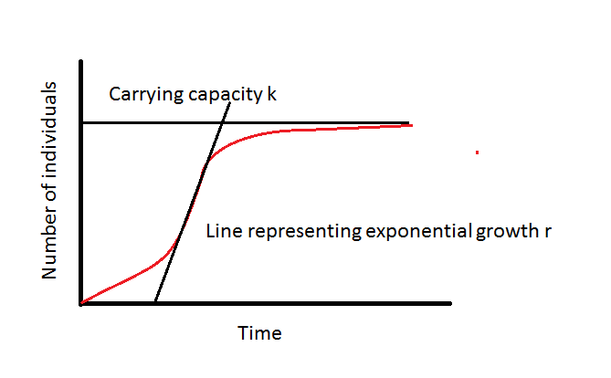

# R/ RStudio Orientation

- Script, Console, Environment, Help
- R basics
  - making objects
  - Object types
    - numeric, character, factor, vector, data.frame, list
  - for loop
  - functions
    - c() and trick to building a recursive vector
    - head() and tail()

# Pipeline

We will be following this vignette: [Growthcurver](https://cran.r-project.org/web/packages/growthcurver/vignettes/Growthcurver-vignette.html)

## Pipeline breakdown:

1. Setup script
2. Load data
3. Organize data for growthcurver
4. Run growthcurver
5. Plot growthcurver output
6. PCA & plot
7. Sigma histogram
8. Plot parameters

## LAA-E2.xlsx

### 1. Setup script

```r
options(stringsAsFactors = F)
#total wells
tw<-96
#filename
fn<-"data/LAA-E2.xlsx"
#replicates?
x<-3
#number of antibiotic concentrations
nc<-12
#number of strains #JUST AURLI
ns<-1
```

### 2. Load data

```r
library("tidyverse")
```

```r
library("readxl")

sheets <- excel_sheets(fn)


exceltable <- sheets  %>%
  as.list() %>%
  map(read_excel,path=fn,col_names = FALSE) %>%
  map(as_tibble)
```

```
## * `` -> ...1
## * `` -> ...2
## * `` -> ...3
## * `` -> ...4
## * `` -> ...5
## * ... and 8 more problems
```

[output not shown]

[output cut: 35 more lines]

[output not shown]

```r
names(exceltable) <- paste("t-", sheets, sep = "")


sheetslist <- exceltable %>%
  map(slice,27:34) %>% #This selects the OD values
  map(select,-1)



for (i in 1:length(sheetslist)){
  colnames(sheetslist[[i]]) <- as.character(c(paste0(0,1:9),10:12))
  sheetslist[[i]]$rows <- LETTERS[1:8]
  sheetslist[[i]] <- sheetslist[[i]] %>% gather(1:12,key="column",value="OD")
}

sheetslist <- sheetslist %>%
  map(as.tibble) %>%
  map(mutate,well=paste0(rows,column)) %>%
  map(mutate,OD=as.numeric(OD))
```

AllSheets is a list of dataframes. Each dataframe contains a value for OD, well, row and column.

```r
sheetslist[[1]] %>%
  head()
```

```
## # A tibble: 6 x 4
##   rows  column     OD well
##   <chr> <chr>   <dbl> <chr>
## 1 A     01     0.120  A01
## 2 B     01     0.114  B01
## 3 C     01     0.155  C01
## 4 D     01     0.117  D01
## 5 E     01     0.0792 E01
## 6 F     01     0.0966 F01
```

You can filter your wells using the filter condition, by row, column or both.

```r
#Select only the first 3 rows
allSheets <- sheetslist %>%
 map(filter,rows==c("A","B","C")) %>%
  map(arrange,well)

allSheets[[1]] %>%
  head()
```

```
## # A tibble: 6 x 4
##   rows  column     OD well
##   <chr> <chr>   <dbl> <chr>
## 1 A     01     0.120  A01
## 2 A     04     0.0416 A04
## 3 A     07     0.0818 A07
## 4 A     10     0.0405 A10
## 5 B     01     0.114  B01
## 6 B     04     0.0419 B04
```

### 3. Organize data for growthcurver

```r
#calculate difference in time
timelist <- exceltable  %>%
  map(select,2) %>%
  map(slice,23:24)

vec <- timelist %>%
  unlist()
vec <- vec[!is.na(vec)]

library(lubridate)
time <- data.frame(ID=sheets,
                   time = mdy_hms(vec)) %>%
  as_tibble() %>%
  arrange(time)%>%
  mutate(dur = time - time[1]) %>%
  mutate(dur=as.duration(dur)) %>%
  mutate(dur=as.numeric(dur,"hours"))
```

what does time look like?

```r
time %>% head()
```

```
## # A tibble: 6 x 3
##   ID               time                    dur
##   <chr>            <dttm>                <dbl>
## 1 LAA-E2-S1-T01-P1 2015-11-13 12:49:00  0
## 2 LAA-E2-S1-T02-P1 2015-11-13 12:51:19  0.0386
## 3 LAA-E2-S1-T03-P1 2015-11-13 12:53:06  0.0683
## 4 LAA-E2-S1-T04-P1 2015-11-13 22:55:33 10.1
## 5 LAA-E2-S1-T05-P1 2015-11-14 15:27:31 26.6
## 6 LAA-E2-S1-T06-P1 2015-11-14 21:30:52 32.7
```

```r
allSheets1 <- allSheets %>%
  map(select,well,OD)%>%
  map(spread,key="well",value="OD")

df <- bind_rows(allSheets1, .id = "ID") %>%
  arrange(ID) %>%
  as.data.frame()

t <- time %>%
  arrange(ID)%>%
  select(-ID) %>%
  as.data.frame()

final <- cbind(t,df) %>%
  as_tibble() %>%
  select(-ID,-time) %>%
  rename(time=dur) %>%
  mutate(time=as.numeric(time))%>%
  as.data.frame()
```

what does final look like?

```r
final %>%
  head()
```

```
##          time    A01    A04    A07    A10    B01    B04    B07    B10    C01
## 1  0.00000000 0.0374 0.0443 0.0385 0.0387 0.0406 0.0464 0.0394 0.0393 0.0418
## 2  0.03861111 0.0389 0.0449 0.0385 0.0379 0.0394 0.0463 0.0385 0.0395 0.0457
## 3  0.06833333 0.0391 0.0462 0.0395 0.0385 0.0402 0.0495 0.0393 0.0400 0.0417
## 4 10.10916667 0.0412 0.0440 0.0391 0.0393 0.0406 0.0439 0.0389 0.0390 0.0429
## 5 26.64194444 0.0722 0.0431 0.0400 0.0397 0.2426 0.0450 0.0395 0.0394 0.2355
## 6 32.69777778 0.2557 0.0433 0.0396 0.0396 0.3796 0.0441 0.0536 0.0384 0.3752
##      C04    C07    C10
## 1 0.0474 0.0422 0.0402
## 2 0.0482 0.0404 0.0395
## 3 0.0499 0.0402 0.0404
## 4 0.0443 0.0403 0.0398
## 5 0.0451 0.0412 0.0404
## 6 0.0441 0.0419 0.0400
```

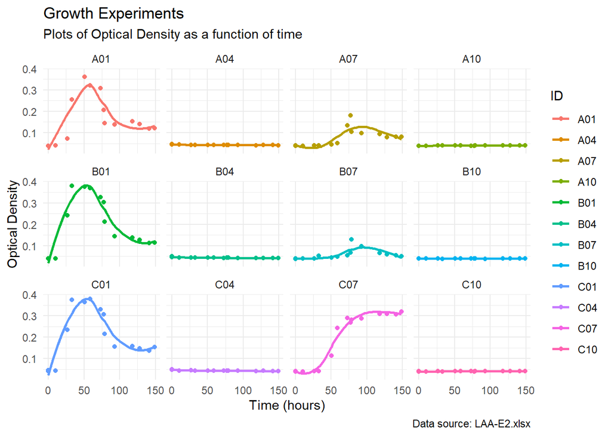

```r
table1 <- final %>% as_tibble() %>%
  gather(2:dim(final)[2],key = "ID",value="OD")


table1 %>% ggplot(aes(x=time,y=OD,color=ID))+
  geom_point()+
  facet_wrap(.~ID)+
  theme_minimal()+
  geom_smooth(se=FALSE)+
  labs(title = "Growth Experiments",
              subtitle = "Plots of Optical Density as a function of time",
              caption = "Data source: LAA-E2.xlsx",x="Time (hours)",y="Optical Density")
```

### 4.Run growthcurver

Take a look at the vignettes for growthcurver [Growthcurver vignettes](https://cran.r-project.org/web/packages/growthcurver/vignettes/Growthcurver-vignette.html)

```r
library("growthcurver")
gc_out <- SummarizeGrowthByPlate(final)
```

what does gc_out look like?

```r
gc_out %>%
  head()
```

```
##   sample           k           n0          r     t_mid     t_gen      auc_l
## 1    A01 0.168751162 4.276198e-17 1.29647692  27.69934  0.534639 20.4558933
## 2    A04 0.001499999 3.067910e-03 0.01641622 -40.88960 42.223322  0.2846144
## 3    A07 0.068173039 8.154181e-17 0.56156530  61.18560  1.234313  5.9810260
## 4    A10 0.002071613 5.131656e-04 0.14637824   7.58888  4.735316  0.2887522
## 5    B01 0.197771807 4.297463e-04 0.35850848  17.09722  1.933419 26.0693545
## 6    B04 0.001599999 5.244593e-03 0.03094241 -11.76226 22.401200  0.2992986
##        auc_e        sigma                      note
## 1 20.6634118 0.0787390901
## 2  0.1949968 0.0009334011 questionable fit (k < n0)
## 3  5.3204288 0.0254546373
## 4  0.2950915 0.0004539442
## 5 25.0220222 0.1010221596
## 6  0.2454720 0.0011268840 questionable fit (k < n0)
```

Additional parameters provided in gc_out

t_mid *= t, ½ K,* the time at which the population density reaches half the carrying capacity

t_gen = doubling time, the least amount of time required to double the population

auc_l = the area under the modeled logistic curve (integral of the logistic equation)

auc_e = the area under the curve obtained from the optical density readings data

sigma = residual standard deviation, the estimated standard deviation of the errors // residual sum of squares from the fit of the logistic curve to the data, so larger values mean poorer fits, a parameter used to evaluate the ‘goodness of fit’

```r
write.csv(gc_out,file="results/aurli_growthcurver_output.csv")
save(gc_out,file="results/aurli_growthcurver_output.rda")
```

```r
d<-final
gc_out <- SummarizeGrowthByPlate(d, plot_fit = TRUE,
                                 plot_file = "results/gc_plots.pdf")
```

```r
# Let's create an output data frame to store the results in.
# We'll create it so that it is the right size (it's faster this way!),
# but leave it empty.
num_analyses <- length(names(d)) - 1
d_gc <- data.frame(sample = character(num_analyses),
                   k = numeric(num_analyses),
                   n0  = numeric(num_analyses),
                   r = numeric(num_analyses),
                   t_mid = numeric(num_analyses),
                   t_gen = numeric(num_analyses),
                   auc_l = numeric(num_analyses),
                   auc_e = numeric(num_analyses),
                   sigma = numeric(num_analyses),
                   stringsAsFactors = FALSE)

# Truncate or trim the input data to observations occuring in the first 20 hours.
# Remember that the times in these sample data are reported in hours. To use
# minutes (or to trim at a different time), change the next line of code.
# For example, if you still would like to trim at 20 hours, but your time data
# are reported in minutes use: trim_at_time <- 20 * 60

trim_at_time<- as.numeric(max(time$dur))#set our preferred plotting range based on tdif


#pdf("results/LAA-E2_growthcurver_r.pdf", height = 8.5, width = 11)

par(mfrow = c(8,12))
par(mar = c(0.25,0.25,0.25,0.25))
y_lim_max <- max(d[,setdiff(names(d), "time")]) - min(d[,setdiff(names(d), "time")])

n <- 1    # keeps track of the current row in the output data frame
for (col_name in names(d)) {

  # Don't process the column called "time".
  # It contains time and not absorbance data.
  if (col_name != "time") {

    # Create a temporary data frame that contains just the time and current col
    d_loop <- d[, c("time", col_name)]

    # Do the background correction.
    # Background correction option 1: subtract the minimum value in a column
    #                                 from all measurements in that column
    min_value <- min(d_loop[, col_name])
    d_loop[, col_name] <- d_loop[, col_name] - min_value
    # Background correction option 2: subtract the mean value of blank wells
    #                                 over the course the experiment
    #                                 (Replace B2, D8, G11 with the column
    #                                  names of your media-only wells)
    #d$blank <- apply(d[, c("B2", "D8", "G11")], 1, mean)
    #d$A1 <- d$A1 - d$blank

    # Now, call Growthcurver to calculate the metrics using SummarizeGrowth
    gc_fit <- SummarizeGrowth(data_t = d_loop[, "time"],
                              data_n = d_loop[, col_name],
                              t_trim = trim_at_time,
                              bg_correct = "none")

    # Now, add the metrics from this column to the next row (n) in the
    # output data frame, and increment the row counter (n)
    d_gc$sample[n] <- col_name
    d_gc[n, 2:9] <- c(gc_fit$vals$k,
                      gc_fit$vals$n0,
                      gc_fit$vals$r,
                      gc_fit$vals$t_mid,
                      gc_fit$vals$t_gen,
                      gc_fit$vals$auc_l,
                      gc_fit$vals$auc_e,
                      gc_fit$vals$sigma)
    n <- n + 1

    # Finally, plot the raw data and the fitted curve
    # Here, I'll just print some of the data points to keep the file size smaller
    ggplot(as.data.frame(gc_fit$data),aes(x=t,y=N))+
      xlim(c(0, trim_at_time))+
      ylim(c(0, y_lim_max))+
      geom_point()+
      theme_minimal()+
      labs(title=col_name)
  }
}

#dev.off()
```

### 6. PCA and plot

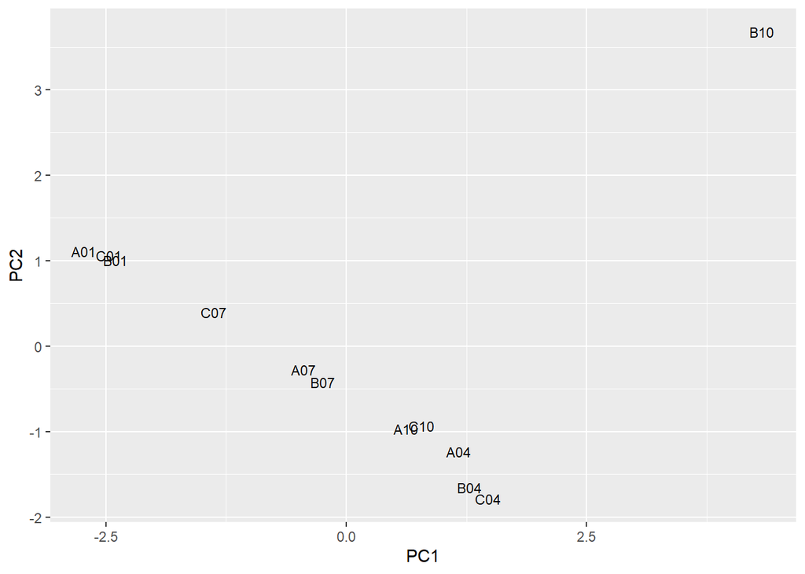

```r
# Load dplyr, ggplot2, and the sample data
library(dplyr)
library(ggplot2)
pca_gc_out <- as_data_frame(gc_out)
# Prepare the gc_out data for the PCA
rownames(pca_gc_out) <- pca_gc_out$sample
# Do the PCA
pca.res <- prcomp(pca_gc_out %>% select(k:sigma), center=TRUE, scale=TRUE)
# Plot the results
as_data_frame(list(PC1=pca.res$x[,1],
                   PC2=pca.res$x[,2],
                   samples = rownames(pca.res$x))) %>%
  ggplot(aes(x=PC1,y=PC2, label=samples)) +
  geom_text(size = 3)
```

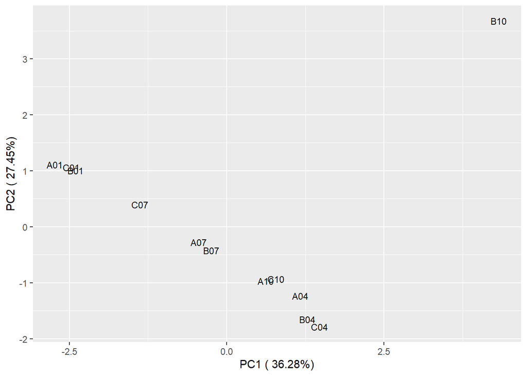

```r
# Do the PCA with percentages in axes
pca.res <- prcomp(pca_gc_out %>% select(k:sigma), center=TRUE, scale=TRUE)
percentage <- round(pca.res$sdev / sum(pca.res$sdev) * 100, 2)
df_out <- as.data.frame(pca.res$x)
percentage <- paste( colnames(df_out), "(", paste( as.character(percentage), "%", ")", sep="") )
# Plot the results
as_data_frame(list(PC1=pca.res$x[,1],
                   PC2=pca.res$x[,2],
                   samples = rownames(pca.res$x))) %>%
  ggplot(aes(x=PC1,y=PC2, label=samples)) + geom_text(size = 3) + xlab(percentage[1]) + ylab(percentage[2])
```

### 7. Sigma histogram

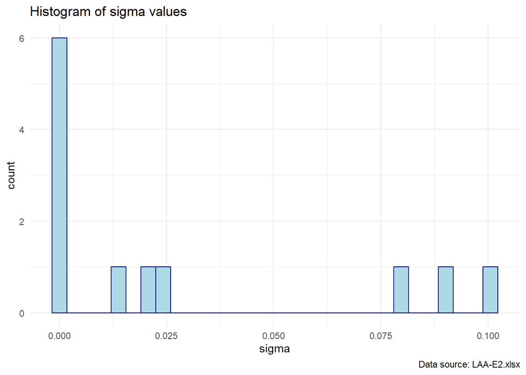

```r
# Plot a histogram of the sigma values in order to check for outliers
gc_out %>%
  ggplot(aes(x=sigma))+
  theme_minimal()+
  labs(title = "Histogram of sigma values",
              caption = "Data source: LAA-E2.xlsx")+
  geom_histogram(fill="lightblue",col="darkblue")
```

### 8. Plot parameters

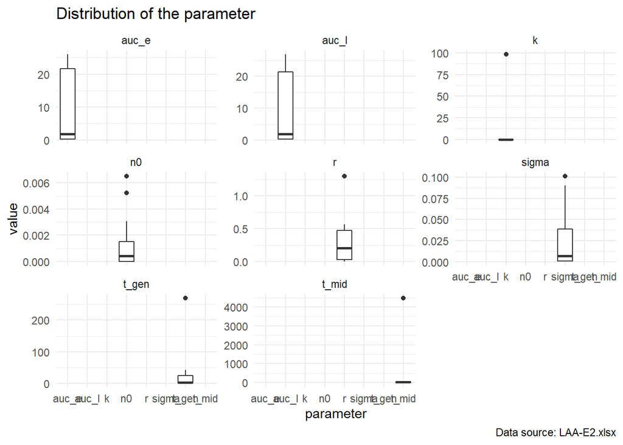

```r
gc_out %>%
  gather(2:9,key="parameter",value = "value") %>%
  select(-note) %>%
  ggplot(aes(y=value,x=parameter))+
  theme_minimal()+
  facet_wrap(.~parameter,scales="free_y")+
  labs(title = "Distribution of the parameter",
              caption = "Data source: LAA-E2.xlsx")+
  geom_boxplot()
```